# Tutorial 7: Logistic Regression and Time Series Forecasting

Haowei

Due by October 17, 9:00 AM

## Part Two: Assignment Submission (25 points)

### Question 3 (total 17 points)

We will study fertility rates with two time-series datasets on U.S. and Singapore, respectively.

High fertility rate is essential for long-term growth in any economy. Many countries are troubled with low or even negative fertility rate. For example, the fertility rate in Singapore in general shows a decreasing trend in recent decades (https://www.channelnewsasia.com/news/singapore/number-of-babies-born-in-singapore-falls-to-lowest-in-8-years-11743722). Fertility is affected by many socio-economic factors, including single rate, family disposable income, level of tax duty, war attrition, contraception technology, etc.

Let’s first take a look at the fertility rate in the United States in 20th century. `fertil3` data contains information about woman’s fertility rate and personal tax exemption in U.S. in early-mid 1900s.

- Dataset required: `data('fertil3')` in `wooldridge` package.

(Note: This dataset comes from a publicly available dataset from Jeffery Wooldridge Textbook. See data description in https://rdrr.io/cran/wooldridge/man/fertil3.html)

First, load in the time series data for this question. There are 72 observations on 24 variables about women fertility rate between year 1913 and 1984. Key variables are listed below:

- `gfr`: births per 1000 women between age 15 and 44.
- `pe`: real value personal tax exemption in US dollars.
- `pe_1`: 1-period lag of `pe`, real value personal tax exemption in US dollars from last year.
- `pe_2`: 2-period lag of `pe`, real value personal tax exemption in US dollars from two years ago.
- `ww2`: a binary variable = 1 during World War 2 between 1941 and 1945.
- `pill`: a binary variable = 1 from 1963 on when the birth control pill was made available for contraception.

```r
# read dataset into workplace, note that you need library(wooldridge) to load this data set
data('fertil3')
# if you want, is can be converted to ts object
fertil = ts(fertil3, frequency = 1, start = 1913)
```

Q3(a) Start off by plotting `gfr` (fertility rate) and `pe_1` (personal tax exemption from last year) against time in the same plot. What do you observe from the time series plots alone: do you see any trend or seasonality? Do you think that `gfr` time series is stationary? (2 points)

Remark: You should be able to visualize data with R base graphics at least. Other alternative R graphic packages such as `ggplot` are welcomed additions.

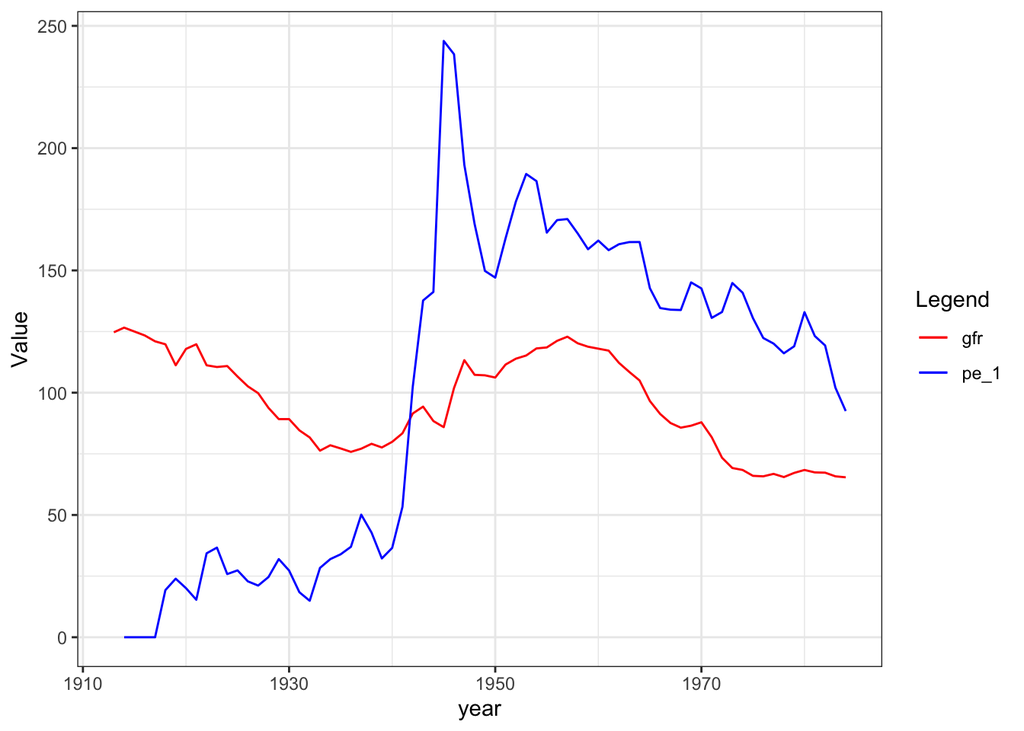

```r
ggplot(fertil3,aes(x=year))+
  ylab("Value") +
  geom_line(aes(y=gfr,colour='gfr'))+
  geom_line(aes(y=pe_1,colour='pe_1'))+
  scale_colour_manual(name='Legend',values = c('gfr'='red','pe_1'='blue'))+
  theme_bw()
```

```r
# plot.ts(fertil[,'gfr'])
# plot.ts(fertil[,'pe'])
# ts.plot(fertil[,'gfr'], fertil[,'pe'],
         #gpars = list(xlab = 'Year', ylab = 'Value', col = c('darkred','darkblue')))
# legend("topright", legend = c('gfr', 'pe'), col = c('darkred','darkblue'), lty = 1)

adf.test(fertil[,"gfr"])
```

```
##
##  Augmented Dickey-Fuller Test
##
## data:  fertil[, "gfr"]
## Dickey-Fuller = -1.8829, Lag order = 4, p-value = 0.623
## alternative hypothesis: stationary
```

Both `gfr` and `pe` exhibit long-term trend. Between 1913 and 1938, gfr had a decreasing trend while pe had a increasing trend and from 1938 on, gfr and pe moved in the same direction with pe being more volatile. `gfr` has a nonlinear trend and shows sign of autocorrelation, thus likely non-stationary.  
Using Augmented Dickey-Fuller Test for unit-root of `gfr` : The large p-value of ADF test shows little evidence that we can reject the null hypothesis, i.e. there exists a unit root for time series `gfr`.

Q3(b) Many labor economists believe that fertility rate is affected by the economic policy such as personal tax exemption, e.g., `pe` and their lag terms. Run a linear regression of `gfr` on `pe`, `pe_1`, and `pe_2`. Interpret the coefficient before `pe`. Is it statistically significant? What’s your conclusion about whether tax exemption improves fertility rate, from the regression output? (3 points)

```r
fit_1 <- lm(gfr ~ pe + pe_1 + pe_2, fertil3)
summary(fit_1)
```

```
##
## Call:
## lm(formula = gfr ~ pe + pe_1 + pe_2, data = fertil3)
##
## Residuals:
##     Min      1Q  Median      3Q     Max
## -30.146 -16.062  -0.127  17.562  31.842
##
## Coefficients:
##             Estimate Std. Error t value Pr(>|t|)
## (Intercept) 93.15791    4.49965  20.703   <2e-16 ***
## pe          -0.01584    0.14026  -0.113    0.910
## pe_1        -0.02134    0.21523  -0.099    0.921
## pe_2         0.05390    0.13811   0.390    0.698
## ---
## Signif. codes:  0 '***' 0.001 '**' 0.01 '*' 0.05 '.' 0.1 ' ' 1
##
## Residual standard error: 19.78 on 66 degrees of freedom
##   (2 observations deleted due to missingness)
## Multiple R-squared:  0.006135,   Adjusted R-squared:  -0.03904
## F-statistic: 0.1358 on 3 and 66 DF,  p-value: 0.9383
```

Coefficient of `pe` = -0.01584. Every unit increase of real value personal tax exemption in US dollars decreases the births per 1000 women between age 15 and 44 by 0.01584, on average, given all other predictors constant.  
However, the p-value=0.910 > 0.05, thus we do not have sufficient evidence to reject the null hypothesis that the coefficient is 0. Therefore, the coefficient is statistically insignificant at the 5% level of confidence.  
From the regression output, it seems that tax exemption does not improve fertility rate as there is no relationship between fertility rate and tax exemption.

Q3(c) Now, include a time trend variable `t` into the regression model in part (b). Interpret the coefficients for `pe_2` and `t`. What’s been changed in the regression result compared to previous one, in terms of coefficients (its sign and magnitude), goodness-of-fit R-square and F-test of the linear regression model? Which model do you think we should choose, and why? (4 points)

```r
fit_2 <- lm(gfr ~ pe + pe_1 + pe_2 + t, fertil3)
summary(fit_2)
```

```
##
## Call:
## lm(formula = gfr ~ pe + pe_1 + pe_2 + t, data = fertil3)
##
## Residuals:
##     Min      1Q  Median      3Q     Max
## -32.295  -8.483   1.330   6.966  20.187
##
## Coefficients:
##               Estimate Std. Error t value Pr(>|t|)
## (Intercept) 109.800159   3.225685  34.039  < 2e-16 ***
## pe            0.008061   0.087085   0.093 0.926533
## pe_1         -0.067940   0.133665  -0.508 0.612973
## pe_2          0.309055   0.089224   3.464 0.000948 ***
## t            -1.068292   0.103606 -10.311  2.6e-15 ***
## ---
## Signif. codes:  0 '***' 0.001 '**' 0.01 '*' 0.05 '.' 0.1 ' ' 1
##
## Residual standard error: 12.28 on 65 degrees of freedom
##   (2 observations deleted due to missingness)
## Multiple R-squared:  0.6229, Adjusted R-squared:  0.5997
## F-statistic: 26.84 on 4 and 65 DF,  p-value: 3.642e-13
```

As we have discussed fertility rate in U.S. between 1913 and 1984 in previous question, now let’s turn our attention to fertility rate in Singapore in modern times, where the fertility rate plummets to lowest figure in 2020 in history.

- Dataset required: `SGfertil20.csv`

Note: This dataset comes from publicly available data from the Singapore Department of Statistics, or SingStat. https://www.singstat.gov.sg/find-data/search-by-theme/population/births-and-fertility/latest-data. You can download the data yourself and explore. For homework, I have done some data cleaning as to have only one time series variable ,`gfr`, in `sgfertil.csv` which contains information on fertility rate of childbearing age women between age 15 and 44 in Singapore comparable to that in U.S.

```r
# read raw data from 'sgfertil.csv'
sgfertil = read.csv(file = 'SGfertil20.csv', header= TRUE)
colnames(sgfertil)[1]='Data.Series'

sgfertil = sgfertil %>%
  # given our focus in univariate time-series analysis on total fertility rate..
  select(Data.Series, Total.Fertility.Rate..Per.Female.) %>%
  # rename
  rename(year = Data.Series, gfr = Total.Fertility.Rate..Per.Female.) %>%
  # sort the data bt ascending on year
  arrange(year)
# extract the key time series of our interest and convert it to ts obj
gfrsg_ts = ts(sgfertil$gfr, start = 1960, end = 2020, frequency = 1)
```

Q3(d) First plot the `gfrsg` against time. Draw the time series plot of `gfrsg`. Describe what you observe from the plot: do you see any trend or/and seasonality? Do you think total fertility rate time series in Singapore `gfrsg` stationary? (2 points)

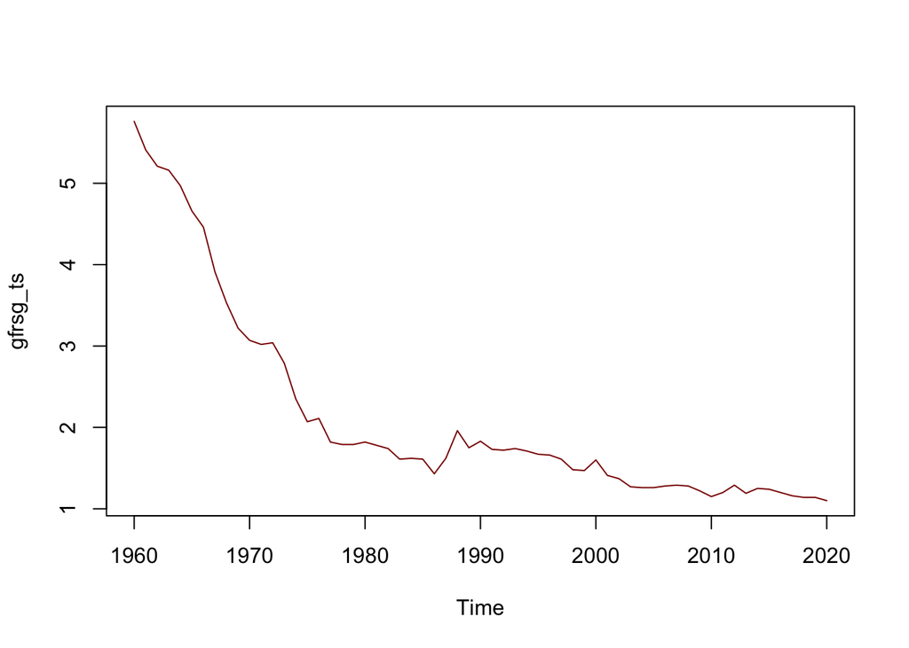

```r
plot.ts(gfrsg_ts, col = 'darkred')
```

Total fertility rate in Singapore clearly shows a decreasing long-term trend. There seems to be no obvious seasonality in the time series data of `gfrsg`. With the decreasing trend, `gfrsg` is unlikely to be stationary.

Q3(e) In order to predict future fertility rate using information contained in the time series of `gfrsg` itself, let’s make forecast by simply fitting a moving average series. First, compute the moving averages with window length of 4 years and plot both the original and moving average series in the same graph. Second, obtain the moving average prediction series. What is the MA predicted value for Year 2021? (3 points)

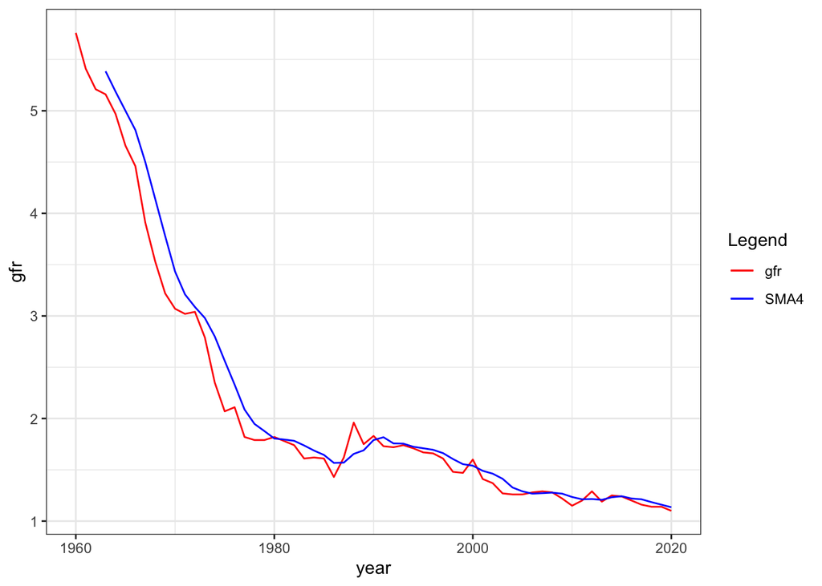

```r
# Take note n is 4 here because each year is one unit, compared to Lab7 where each time period was 1/4 of a year
sgfertil$SMA4 = TTR::SMA(sgfertil$gfr, n=4)


ggplot(sgfertil,aes(x=year))+
  geom_line(aes(y=gfr,colour='gfr'))+
  geom_line(aes(y=SMA4,colour='SMA4'))+
  scale_colour_manual(name='Legend',values = c('gfr'='red','SMA4'='blue'))+
  theme_bw()
```

```r
# Obtaining moving average prediction Series using window length of 4 years
# Window4 = 1/4 (Yt + Yt−1 + Yt-2 + Yt−3)

sgfertil$SMA4_predict = dplyr::lag(sgfertil$SMA4,1) # moving average prediction series
sgfertil$SMA4_predict
```

```
##  [1]     NA     NA     NA     NA 5.3850 5.1875 5.0000 4.8125 4.5000 4.1400
## [11] 3.7800 3.4325 3.2100 3.0875 2.9800 2.8000 2.5625 2.3300 2.0875 1.9475
## [21] 1.8775 1.8050 1.7950 1.7825 1.7375 1.6875 1.6450 1.5675 1.5700 1.6550
## [31] 1.6900 1.7900 1.8175 1.7575 1.7550 1.7250 1.7100 1.6950 1.6625 1.6050
## [41] 1.5550 1.5400 1.4900 1.4625 1.4125 1.3275 1.2900 1.2675 1.2725 1.2775
## [51] 1.2675 1.2350 1.2125 1.2150 1.2075 1.2325 1.2425 1.2200 1.2125 1.1850
## [61] 1.1600
```

```r
# MA Predicted value for Year 2021
sgfertil %>% filter(year == 2020) %>% select(SMA4)
```

```
##    SMA4
## 1 1.135
```

The MA predicted value for Year 2021 is 1.135.

Q3(f) Based on your observation in part (d), predict the fertility rates for Year 2021 and Year 2024 with Holt-Winter model of your choice. (3 points)

```r
hw1 = HoltWinters(gfrsg_ts, gamma = FALSE)
hw1
```

```
## Holt-Winters exponential smoothing with trend and without seasonal component.
##
## Call:
## HoltWinters(x = gfrsg_ts, gamma = FALSE)
##
## Smoothing parameters:
##  alpha: 1
##  beta : 0.2165719
##  gamma: FALSE
##
## Coefficients:
##          [,1]
## a  1.10000000
## b -0.01932966
```

```r
# prediction model
hw1_pred <- predict(hw1, n.ahead = 4)

# Predicting fertility rates for Year 2021 using indexing
hw1_pred[1]
```

```
## [1] 1.08067
```

```r
# Predicting fertility rates for Year 2024 using indexing
hw1_pred[4]
```

```
## [1] 1.022681
```

The predicted fertility rate for Year 2021 is 1.08067.  
The predicted fertility rate for Year 2024 is 1.022681.

### Question 4 (Total 8 points)

- Dataset required: `data('recid')`

Recidivism rate in Singapore is 24% in 2016 (https://data.gov.sg/dataset/recidivism-rate). Criminals tend to relapse into criminal offense after the release from the prison. Recidivism is costly and causes serious social and economical problem. It is not only wasteful with the resources invested in prison, including staffing, infrastructure investment, daily operation cost, and economic opportunity cost for both prisoners and staffs (i.e., labor values that could be generated elsewhere other than being locked up and guarding in prison, respectively), but also harms the community for the second time due to crime re-commitment. Recidivism is thus a critical evaluating metric for prison performance, e.g., rehabilitation or training program. `recid.csv` contains 1445 observations of recidivism cases in United States where it currently has the largest prison population in the world (about one out every five peope imprisoned in the world is incarcerated in the United States).

```r
recid = read.csv(file = 'recid.csv', header= TRUE)
```

C.-F. Chung, P. Schmidt, and A.D. Witte (1991), “Survival Analysis: A Survey,” Journal of Quantitative Criminology 7, 59-98. Data Source: https://www.cengage.com/cgi-wadsworth/course_products_wp.pl?fid=M20b&product_isbn_issn=9781111531041. A quick description of the data:

Obs: 1445

1. black =1 if black
2. alcohol =1 if alcohol problems
3. drugs =1 if drug history
4. super =1 if release supervised
5. married =1 if married when incarc.
6. felon =1 if felony sentence
7. workprg =1 if in N.C. pris. work prg.
8. property =1 if property crime
9. person =1 if crime against person
10. priors # prior convictions
11. educ years of schooling
12. rules # rules violations in prison
13. age in months
14. tserved time served, rounded to months
15. follow length follow period, months
16. durat max(time until return, follow) in month
17. cens =1 if duration right censored
18. ldurat log(durat)

Q4(a) Criminal offense lawyers usually fight for supervised release of the offender. Given five variables in `recid` data set: `super`, `rules`, `age`, `tserved`, `married`, `priors` and `black`, how could you help the law firm to predict the outcome of a recent case given that a 55-year-old married black client has been serving the jail time for 5 years and 11 months with no prior conviction and during which broken no rule in the prison? In order to evaluate the likelihood to answer such question. First of all, write down the regression model you propose to use. Clearly define or label your variables. (2 point)

```r
# Proposed regression model
# Use GLM with Binomial Family as dependent variable is categorical (Binary dependent variable)
fit_supervisedRelease <- glm(super ~ rules+age+tserved+married+priors+black, family = binomial ,data=recid)
```

For this question, we are interested in predicting the outcome of a binary dependent variable (i.e., Released Supervised or Not Released Supervised). Hence, we can conduct a logistic regression. Our logistic regression model is: logit(p) = log (p/(1-p)) = b0 + b1`rules` + b2`age` + b3`tserved` + b4`married` + b5`priors` + b6`black`, where p is the probability of an offender being released supervised.  
**NOTE: for Log regression, it is BETA not b**

Q4(b) Run your regression model in R and interpret the coefficients before `priors` and `black`. Based on the results, do you think there was any racial discrimination in terms of likelihood of supervised release, and why? (3 point)

```r
summary(fit_supervisedRelease)
```

```
##
## Call:
## glm(formula = super ~ rules + age + tserved + married + priors +
##     black, family = binomial, data = recid)
##
## Deviance Residuals:
##     Min       1Q   Median       3Q      Max
## -2.9687  -1.2588   0.7161   0.8627   1.9158
##
## Coefficients:
##               Estimate Std. Error z value Pr(>|z|)
## (Intercept)  0.7854986  0.2065112   3.804 0.000143 ***
## rules       -0.2389832  0.0359476  -6.648 2.97e-11 ***
## age         -0.0008911  0.0005515  -1.616 0.106171
## tserved      0.0342718  0.0049966   6.859 6.93e-12 ***
## married      0.4791923  0.1469812   3.260 0.001113 **
## priors      -0.0943194  0.0237489  -3.972 7.14e-05 ***
## black        0.1114900  0.1197896   0.931 0.352001
## ---
## Signif. codes:  0 '***' 0.001 '**' 0.01 '*' 0.05 '.' 0.1 ' ' 1
##
## (Dispersion parameter for binomial family taken to be 1)
##
##     Null deviance: 1779.6  on 1444  degrees of freedom
## Residual deviance: 1670.5  on 1438  degrees of freedom
## AIC: 1684.5
##
## Number of Fisher Scoring iterations: 4
```

Coefficient of `priors` = -0.0943194. For every unit increase in number of prior convictions, the log-odds for supervised release of the offender decreases by 0.0943194 given all other predictors constant.  
Moreover, The p-value=7.14e-05(< 0.05), thus we can reject the null hypothesis that this slope parameter is = 0, i.e., the coefficient is significantly different from zero.  
Coefficient of `black` = 0.1114900. If the offender is black, the log-odds for supervised release of the offender increases by 0.1114900 given all other predictors constant.  
However, p-value=0.352001(> 0.05), we cannot reject the null hypothesis that this slope parameter is = 0, i.e., the coefficient is not significantly different from zero.  
According to the model, there was no racial discrimination in terms of likelihood of supervised release as from the regression output, it seems that there is no relationship between being black and the likelihood of supervised release. (Since the two-sided z-test for marginal effect for black fails to reject its null. There is no evidence for racial discrimination regarding the chance for supervised release.)

Q4(c) Finally, what is the predicted probability for supervised release for the new client? (2 point)

```r
newClient = data.frame(rules = 0, age = 55*12, tserved = 71, married = 1, priors = 0, black = 1)
# Evaluating likelihood
# use type = 'response'
predict(fit_supervisedRelease, newdata = newClient, type = 'response')
```

```
##         1
## 0.9616305
```

The predicted probability for supervised release of a 55-year-old married black client has been serving the jail time for 5 years and 11 months with no prior conviction and during which broken no rule in the prison is 0.9616305.

Q4(d) Successfully debug the Rmarkdown file and produce an HTML for submission. (1 point)